# Access to Restorative Reproductive Medicine Practices by Caller Identity: A National Mystery-Caller Study

COMIRB 25-2596 · Denver Health and Hospital Authority

Tyler Muffly, MD

> **Draft manuscript.** Generated 2026-08-11 20:34 MDT from `manuscript.Rmd`. Every statistic is computed at render time from the files in `mysterycall_outputs/`; see `PROVENANCE.md` for the artifact fingerprints and the exact REDCap export behind them.

# Abstract

**Objective.** To characterize the reproductive services offered by Restorative Reproductive Medicine (RRM) practices and to explore whether willingness to schedule a new patient differs by caller identity.

**Methods.** In a national mystery-caller (audit) study, RRM practices were telephoned by trained callers presenting one of three scenarios: a straight couple, a lesbian couple, or a single mother seeking donor sperm. Each practice was eligible to be called once per scenario, making the design within-practice. The primary outcome was whether the practice offered to schedule an appointment; the secondary outcome was business days to the first available appointment. Because scenario assignment is complete only within practices called more than once, inference on caller identity is restricted to exact McNemar tests on within-practice discordant pairs, with a minimum detectable effect reported for each contrast.

**Results.** 234 calls were placed to 106 practices, of which 98 reached a clinician or scheduler and met inclusion criteria. 48 practices completed all three scenarios. Among included calls, cycle tracking was offered by 95% (95% CI 89–98), whereas intrauterine insemination was offered by 1% (95% CI 0–6), in vitro fertilization by 1% (95% CI 0–6), and work with donor sperm by 3% (95% CI 1–9). The overall appointment-offer rate was 42% (95% CI 36–48). Practices treated callers concordantly in 69–80% of within-practice comparisons. No scenario contrast reached significance (all *p* ≥ 0.33), but each was powered only to detect an odds ratio of roughly 3.3–4.6.

**Conclusion.** RRM practices in this sample almost uniformly offer cycle tracking and almost never offer IUI, IVF, or donor sperm services. Scenario comparisons were underpowered and should be read as hypothesis-generating; the unmatched marginal comparison is confounded by which practices received a single-mother call and is not reported.

# 1 Introduction

Restorative Reproductive Medicine (RRM) is a model of fertility care that seeks to identify and treat underlying causes of subfertility rather than to bypass them with assisted reproductive technology. Because the model is defined partly by what it declines to offer, patients seeking care may encounter a narrower service menu than the fertility-clinic label implies, and that gap may fall unevenly across family structures — particularly for patients whose path to pregnancy requires donor gametes.

Mystery-caller (audit) methodology measures what a practice actually does when an unannounced prospective patient calls, avoiding the social-desirability bias of surveying practices about their own behavior. We applied it to RRM practices with two aims: to describe the services actually offered, and to test whether willingness to schedule differs by caller identity.

# 2 Methods

## 2.1 Design and setting

We conducted a national mystery-caller study of RRM practices. Trained callers telephoned each practice during business hours (08:00–17:00 local time, excluding 12:00–13:00) using a standardized script. Each practice was eligible to be called once per scenario, so scenario is a **within-practice** factor and practice enters all models as a random intercept. The study was approved by COMIRB (25-2596).

## 2.2 Scenarios

Three caller identities were used: a **straight couple**, a **lesbian couple**, and a **single mother** seeking donor sperm. Scripts were identical apart from the caller’s stated family structure and the donor-sperm question, which was asked only in the two scenarios where it is clinically implied.

## 2.3 Outcomes

The primary outcome was whether the practice **offered to schedule an appointment**. The secondary outcome was **business days** from the call to the first available appointment, computed with a business-day calendar to avoid weekend and holiday artifacts.

## 2.4 Inclusion

A call was analytically included when `Reason for exclusions` was *“Included where physician was able to be contacted.”* The REDCap `Complete?` field was **not** used as an inclusion criterion: in the current export every record is marked complete, so the field has no discriminating power.

Analytic denominators. Each outcome is estimated on a different subset; the wait-time analyses use a substantially smaller sample than the acceptance analyses.

| Level | n | Practices | Definition |
| --- | --- | --- | --- |
| All call records | 234 | 106 | every row in the REDCap export |
| Analytically included | 98 | 51 | clinician or scheduler reached |
| Wait-time subset | 57 | 37 | included and an appointment date was obtained |
| Within-practice wait pairs | 33 | 13 | wait subset, practices with >= 2 scenarios |

41 included calls produced no appointment date, almost always because the practice did not offer to schedule. Wait-time results therefore describe the subset of encounters that reached scheduling and should not be read as representative of all included calls.

## 2.5 Statistical analysis

**Primary inference is the matched analysis.** For each pair of scenarios we restricted to practices called for both and applied an **exact McNemar test** to the discordant pairs. This is the only comparison in which caller identity is not confounded with practice selection. For each contrast we report the minimum detectable odds ratio at 80% power given the observed number of discordant pairs, so that a null result is not mistaken for evidence of equivalence. Proportions carry Wilson score intervals.

# 3 Results

## 3.1 Sample

Calls placed and analytically included, by scenario.

| Scenario | Calls | Included |
| --- | --- | --- |
| Lesbian couple | 83 | 33 |
| Single mother | 74 | 31 |
| Straight couple | 77 | 34 |

234 calls were placed to 106 practices; 98 met inclusion criteria. 48 practices completed all three scenarios, and 33 of 106 practices have not yet received a single-mother call.

## 3.2 Services offered (primary descriptive findings)

Services offered among analytically included calls (n = 98). Wilson score intervals.

| Service | Estimate |
| --- | --- |
| Cycle tracking | 95% (95% CI 89–98) |
| Hormonal labs / fertility timing | 63% (95% CI 53–72) |
| Ovulation induction | 11% (95% CI 6–19) |
| Intrauterine insemination (IUI) | 1% (95% CI 0–6) |
| In vitro fertilization (IVF) | 1% (95% CI 0–6) |
| Works with donor sperm | 3% (95% CI 1–9) |

These are the study’s most precisely estimated findings and do not depend on the scenario comparison. RRM practices in this sample almost uniformly offer cycle tracking (95% (95% CI 89–98)) while essentially never offering IUI (1% (95% CI 0–6)) or IVF (1% (95% CI 0–6)), and rarely working with donor sperm (3% (95% CI 1–9)). The overall appointment-offer rate across all 234 calls was 42% (95% CI 36–48).

## 3.3 Caller identity and willingness to schedule

### 3.3.1 The unmatched comparison is confounded and is not reported

Marginal (unmatched) acceptance by scenario. Reported here only to be set aside — see text.

| Scenario | Unmatched acceptance |
| --- | --- |
| Lesbian couple | 40% (33/83) |
| Single mother | 42% (31/74) |
| Straight couple | 44% (34/77) |

### 3.3.2 Matched within-practice comparisons

Matched within-practice acceptance comparisons. The MDE column is essential: a non-significant result here excludes only very large effects.

| Contrast | Practices paired | Concordant | Discordant | Exact McNemar p | Min. detectable OR (80% power) |
| --- | --- | --- | --- | --- | --- |
| Straight couple vs Single mother | 54 | 37 | 17 | 0.332 | 3.3 |
| Lesbian couple vs Single mother | 65 | 52 | 13 | 1.000 | 4.6 |
| Straight couple vs Lesbian couple | 50 | 37 | 13 | 0.581 | 4.6 |

Restricted to practices called for both scenarios in a contrast, no comparison approached significance. Concordance — practices treating both callers identically — ranged from 69% to 80%.

| Comparison | Practices | Single mother | Comparator | Difference |
| --- | --- | --- | --- | --- |
| Single mother vs Straight couple | 54 | 43% | 52% | -9 pts |
| Single mother vs Lesbian couple | 65 | 43% | 45% | -2 pts |

## 3.4 Wait times

Business days to first available appointment, among calls that reached scheduling (n = 57).

| Scenario | n | Median | IQR | Mean |
| --- | --- | --- | --- | --- |
| Lesbian couple | 14 | 19.5 | 32.75 | 26.6 |
| Single mother | 15 | 13.0 | 23.50 | 18.1 |
| Straight couple | 28 | 18.0 | 35.50 | 31.6 |

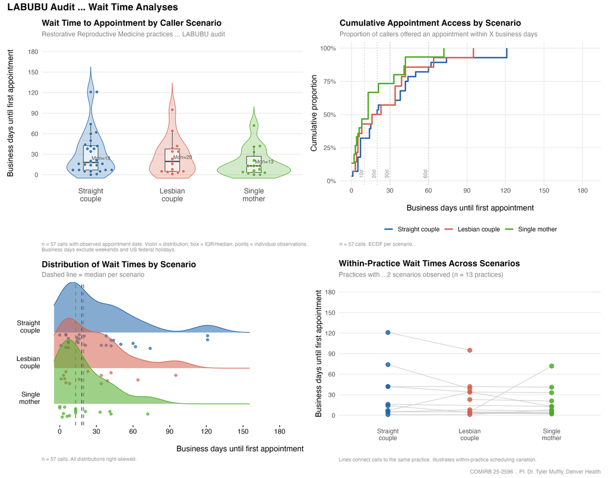

Wait-time analyses. Panels use the wait-time subset; the within-practice panel uses only practices with two or more observed scenarios. See PROVENANCE.md for exact per-figure denominators.

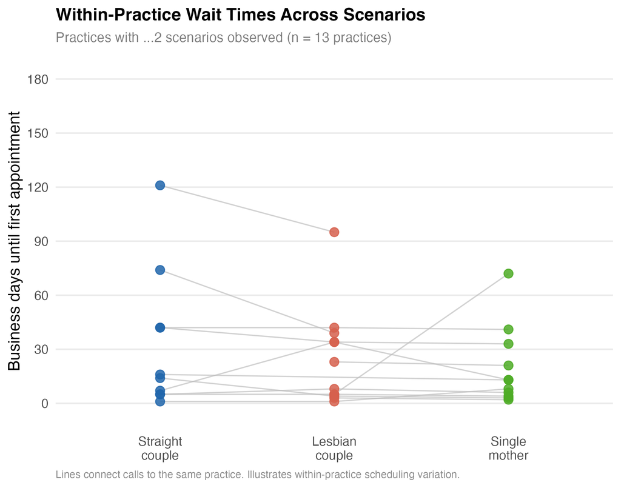

Within-practice wait times across scenarios. Lines connect calls to the same practice.

Wait-time distributions overlapped substantially across scenarios. With 57 observations across 37 practices — and only 13 practices contributing a within-practice comparison — these analyses are the least powered in the study and are presented descriptively.

# 4 Discussion

The most secure findings in this study are descriptive. RRM practices in this sample offer cycle tracking nearly universally and almost never offer IUI, IVF, or donor-sperm services. For a patient whose path to pregnancy requires donor gametes, this is a structural access limitation independent of any differential treatment by staff: the service is largely not on the menu.

Our scenario comparisons were **underpowered by design constraint rather than by oversight**. The matched analysis draws information only from practices that answered *differently* to two callers, and most practices answered identically. With 13–17 discordant practices per contrast, only odds ratios of roughly 3.3–4.6 were detectable. Effects of that magnitude are far larger than plausible real-world differential treatment. These comparisons therefore exclude gross disparity but can neither confirm nor rule out the small-to-moderate effects most likely to exist, and we frame them as hypothesis-generating.

## 4.1 Limitations

1. **Incomplete scenario coverage.** 33 of 106 practices have not received a single-mother call. This is the dominant limitation: it drives the confounding above and caps the matched sample.
2. **Wait-time missingness is informative.** Only 57 of 98 included calls yielded an appointment date, largely because practices that declined to schedule have no date to give. Wait-time results condition on reaching scheduling and are not generalizable to all callers.
3. **Single-call design.** Each practice–scenario cell reflects one call on one day with one staff member; day-to-day and person-to-person variation is not separable from scenario effects.
4. **Ambiguous restriction fields.** The REDCap item asking about restrictions on whom the practice will treat cannot distinguish a restriction *against* a group from a requirement *to be* in that group, so those fields are not analyzed.
5. **Non-response.** Voicemail accounted for most exclusions. Practices reachable by phone may differ systematically from those that are not.

# 5 Reproducibility

Provenance summary. Raw exports are not distributed (practice contact information); PROVENANCE.md records their checksums.

| Item | Value |
| --- | --- |
| Analysis repository | github.com/mufflyt/LABUBU |
| Modeling package | mysterycall v1.6.3 |
| Source export | LABUBU_DATA_LABELS_2026-08-11_2017.csv |
| Artifact record | PROVENANCE.md / mysterycall_outputs/provenance.json |
| Rendered | 2026-08-11 20:34 MDT |

All tables and figures regenerate with `Rscript refresh.R`, which runs the analysis, the figures, and the provenance record in that order. This document is rendered from `manuscript.Rmd`, which reads only generated artifacts — no statistic in the text is transcribed by hand.